# Your first ML question with NowEDA

**Can customer activity help us predict who will leave?** In this example, *churn* means a customer left. The **target** is the answer we want to predict (`churned`). The **features** are the clues we could know beforehand, such as the customer's transaction count and satisfaction score.

Open this notebook beside the included synthetic CSV and choose **Run All**. Use a Python kernel with the project's chart dependencies installed. From the project folder, `pip install -e ".[viz]"` installs them. The main lesson ends at the report. The examples after it are optional.

## Read the customer records

`nrows=5_000` loads the first 5,000 rows so the lesson runs quickly. Each row is a customer record. Preview four columns. The record ID lets us distinguish two customers who happen to give the same satisfaction score.

```python
import noweda as eda

file_name = "test_data_large_with_pii.csv"
records = eda.read(file_name, nrows=5_000)
columns = ["record_id", "transaction_count", "satisfaction_score", "churned"]
records[columns].head()
```

```
[########################] 100% NowEDA · Reading test_data_large_with_pii.csv
```

|  | record_id | transaction_count | satisfaction_score | churned |
| --- | --- | --- | --- | --- |
| 0 | REC-1000000 | 40 | 2.7 | yes |
| 1 | REC-1000001 | 43 | 3.4 | yes |
| 2 | REC-1000002 | 109 | 4.1 | no |
| 3 | REC-1000003 | 162 | 3.2 | no |
| 4 | REC-1000004 | 230 | 4.4 | no |

## Check the data before making predictions

Run `statsall()` on the four columns in the preview. Find **Duplicates** in the **Plugin Summary**. In the bundled example, 25 rows repeat. Repeated records could put the same customer on both sides of a model comparison.

```python
records[columns].eda.statsall()
```

```
[########################] 100% NowEDA · Building full statistical report
```

```
======================================================================
  NowEDA · Full Statistical Report
======================================================================
  Rows    : 5,000
  Columns : 4

Scores
------------------------------------------------------------
  Data Quality    : 97 out of 100
  Model Readiness : 100 out of 100
  Risk            : 0  (0 = no signals detected)

Column Types
------------------------------------------------------------
  Column               Dtype          Role                  Conf   Unique  Missing
  -------------------- -------------- -------------------- ----- -------- --------
  record_id            object         id_candidate          0.92     4975        0
  transaction_count    int64          numeric               0.98      309        0
  satisfaction_score   float64        numeric               0.98       38        0
  churned              object         categorical           0.90        2        0

Descriptive Statistics
------------------------------------------------------------

  Column                  Count         Mean          Std        Min        25%        50%        75%        Max     Skew
  -------------------- -------- ------------ ------------ ---------- ---------- ---------- ---------- ---------- --------
  transaction_count       5,000        118.5        72.01          0         50        116        153        349     0.56
  satisfaction_score      5,000        3.526       0.6782        1.2        3.1        3.5          4          5    -0.13

  Column                  Count   Unique  Diversity Top Value                      Freq %
  -------------------- -------- -------- ---------- ---------------------------- --------
  record_id               5,000     4975 1.00 REC-1000000                      0.0%
  churned                 5,000        2 0.80 no                              75.7%

Insights
------------------------------------------------------------
  • Likely identifier column(s) detected: record_id. Consider excluding from modelling.
  • Column(s) with low cardinality (likely categorical): churned.
  • 25 duplicate row(s) detected (0.5% of data). De-duplication is recommended.
  • Column 'transaction_count' has 12 outlier(s) (IQR method). Review before modelling.
```

[output cut: 27 more lines]

```
  ✓ Low Multicollinearity (all VIF <= 5)

  Scaling Recommended:
    transaction_count   : Use StandardScaler or MinMaxScaler

  Transformation Suggestions: none based on the observed distributions

  Feature Review (Identifiers, PII, Text, and Cardinality):
    record_id           : very high-cardinality likely identifier — exclude from model features.

  Rare Categories: none below 1% prevalence

  Missing Data Strategy: no missing values detected

======================================================================
```

## Can you draw a line between customers who stayed and customers who left?

Remove exact duplicate rows from the original table. Then keep two clues and the outcome for the charts. A record ID is useful for checking the data, so we set it aside when making predictions.

Read the charts from top to bottom.

1. **Class counts.** Which outcome occurs more often, `yes` or `no`?
2. **Logistic curve.** Pick a transaction count and read up to the curve. Its height estimates the chance that a customer leaves.
3. **Straight and curved boundaries.** The dots show customers held back from training. Each cross marks a wrong prediction. Does bending the boundary fix many mistakes?

```
[########################] 100% NowEDA · Rendering visualizations
```

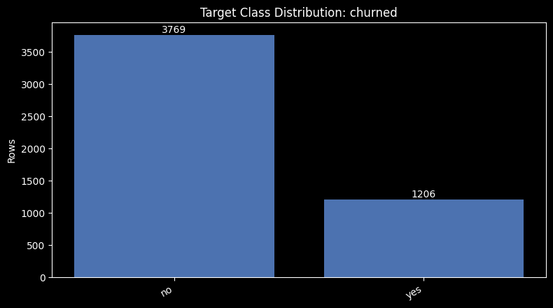

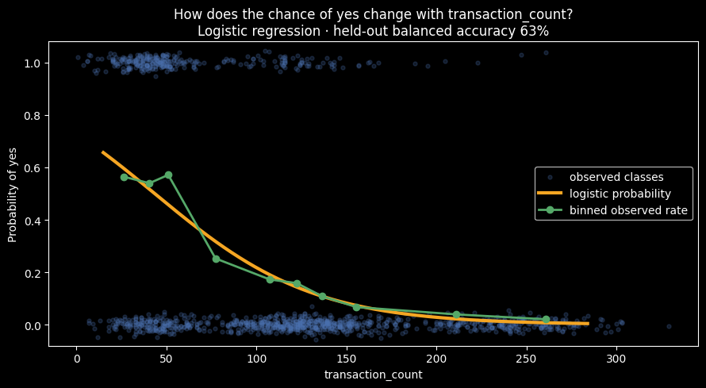

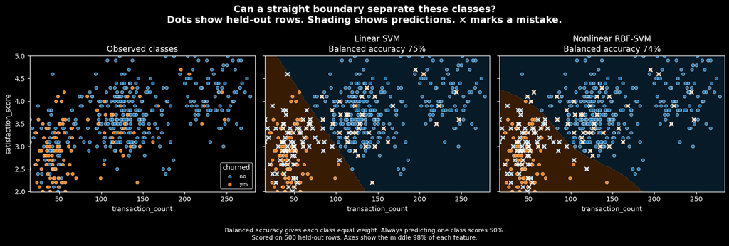

```
Visual ML signals
  - Approximately linear target structure appears in transaction_count, satisfaction_score; logistic regression or a linear SVM is a reasonable baseline to validate.
  - Choose between linear and nonlinear classifiers with stratified validation; visual separation alone is not decisive.
```

```
NowEDA VizResult(target='churned', problem_type='classification', plots=5, selected_features=2)
```

```python
clean = records.drop_duplicates()
churn = clean[["transaction_count", "satisfaction_score", "churned"]]
churn.eda.vizall(target="churned", max_plots=5)
```

## Choose a first model to try

Of the 4,975 records, 1,206 customers left. The curve shows that customers with more transactions were generally less likely to leave. Using both features, the straight boundary scored 75% and the curved one scored 74% on the held-out customers. This score, **balanced accuracy**, gives each of the two outcomes equal weight.

On your own table, you can use `churn.eda.mlall()` to explore possible tasks. Here we know the target. Run the cell below and find **Estimated fit**. The stars suggest models worth testing. Even though boosted trees rank first in the list, the chart gives us a reason to try a straight boundary first and compare the two models on new customers.

```python
churn.eda.mlall(target="churned")
```

```
[########################] 100% NowEDA · Building ML recommendations
```

```
======================================================================
  NowEDA · Task-Aware ML Guidance
======================================================================

  Problem type: classification
  Subtype: binary
  Target: 'churned'
  Usable labels: 4,975 of 4,975
  Inference: categorical or boolean target values. Override problem_type if this does not match your objective.

  Review before modeling:
    • Class counts differ by more than 2:1; use stratified splits and class-aware metrics.

  Candidate methods (ranked by estimated fit)
  --------------------------------------------------------------

  Gradient-Boosted Trees
    Estimated fit: ★★★★★ (4.5/5)
    Why: Strong candidate for nonlinear tabular relationships and mixed feature types.
    Caution: Tune with validation data and early stopping; performance is not established by this recommendation.

  Logistic Regression
    Estimated fit: ★★★★☆ (4.0/5)
    Why: Interpretable probability baseline for binary or multiclass outcomes.
    Caution: Encode categoricals, scale numeric features, and use regularization for correlated features.

  Random Forest Classifier
    Estimated fit: ★★★★☆ (4.0/5)
    Why: Captures nonlinear interactions and provides a robust tree-based baseline.
    Caution: Impute missing values and validate depth to limit overfitting, especially on small data.

  Support Vector Classifier
    Estimated fit: ★★★★☆ (3.5/5)
    Why: Can model complex boundaries on small or medium numeric datasets.
    Caution: Requires scaling and can become expensive as row count grows.

  Preprocessing
  --------------------------------------------------------------
    1. Scale numeric features for distance-, margin-, and component-based methods.
    2. Use class weights or resampling within training folds; never resample validation rows.

  Validation and metrics
  --------------------------------------------------------------
    • Use stratified holdout or stratified cross-validation when every class has enough rows.
    • Compare ROC-AUC, precision-recall AUC, F1, confusion matrix, and probability calibration.

  Guidance is based on data characteristics; no models were trained or measured.
======================================================================


  What the selected features suggest:
    - Approximately linear target structure appears in transaction_count, satisfaction_score; logistic regression or a linear SVM is a reasonable baseline to validate.
    - Choose between linear and nonlinear classifiers with stratified validation; visual separation alone is not decisive.
```

## Look more closely at transaction count

The logistic curve used this feature. Compare its mean and median in the column profile. If they differ, a few customers with unusually high activity may be pulling up the mean.

```python
churn.eda.profile_column("transaction_count")
```

```
[########################] 100% NowEDA · Profiling column 'transaction_count'
```

```
======================================================================
  Column Profile: transaction_count
======================================================================

Type Information:
  Data Type       : int64
  Inferred Role   : numeric (confidence: 0.98)
  Unique Values   : 309
  Missing         : 0 (0.0%)

Numeric Statistics:
  Mean            : 118.5
  Median          : 116
  Std Dev         : 72.04
  Min             : 0
  Max             : 349
  Q1 (25%)        : 50
  Q3 (75%)        : 153

Distribution:
  Shape           : Moderately skewed
  Skewness        : 0.563
  Direction       : Right-skewed (long tail right)
  Recommendation  : Try sqrt or log transformation

======================================================================
```

## Check what cleaning changed

Compare the original records with the cleaned table. Under **Dataset Dimensions**, the row count should go from 5,000 to 4,975 while the number of columns stays the same.

```python
records.eda.compare(clean)
```

```
[########################] 100% NowEDA · Comparing datasets
```

```
======================================================================
  Dataset Comparison
======================================================================

Dataset Dimensions:
  Dataset 1 :  5,000 rows ×  32 columns
  Dataset 2 :  4,975 rows ×  32 columns
  Change    : -25 (-0.5%)

Score Changes:
  data_quality    :  79 →  82  +3
  model_readiness :  35 →  35  +0
  risk            :  85 →  85  +0

PII Detection Changes:

======================================================================
```

## Get a result you can reuse

`report()` returns the findings in a Python dictionary. Retrieve the duplicate count from the cleaned table. A zero here confirms the cleanup worked.

```python
report = clean.eda.report()
report["results"]["duplicates"]["duplicate_rows"]
```

```
[########################] 100% NowEDA · Building report
```

```
0
```

You have enough for a first experiment. Use transaction count and satisfaction score to test a simple straight-line classifier on new customers. Compare a more complex model on the same customers if it might catch mistakes that matter to you.

## Optional · Predict a number

**How much is a customer likely to spend over their lifetime?** Predicting an amount is called **regression**. Read the fitted line, then look at the errors. An error above zero means the customer spent more than the line predicted.

```
[########################] 100% NowEDA · Rendering visualizations
```

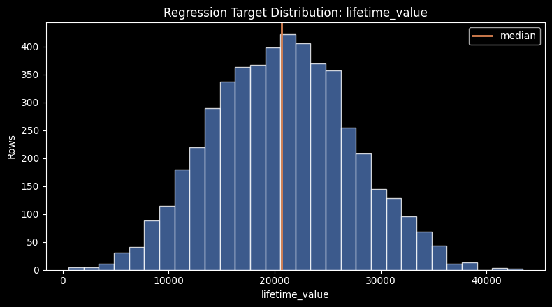

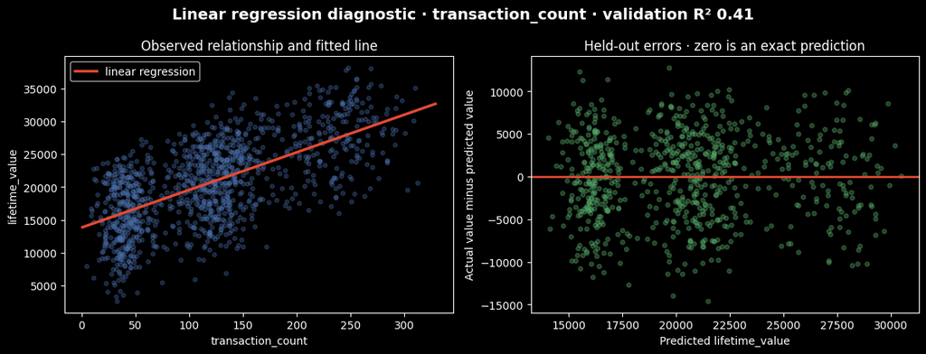

```
Visual ML signals
  - Approximately linear target structure appears in transaction_count; linear regression is a reasonable baseline to validate.
  - Compare linear and nonlinear regressors with validation; residual behavior and predictive metrics decide the final model.
```

```
NowEDA VizResult(target='lifetime_value', problem_type='regression', plots=3, selected_features=1)
```

```python
spending = clean[["transaction_count", "lifetime_value"]]
spending.eda.vizall(target="lifetime_value", max_plots=3)
```

## Optional · Spot a clue that gives away the answer

In the synthetic data, `fraud_risk_score` was created using the final fraud outcome. Using it to predict that outcome would give a model information from the future. This is called **target leakage**. Look for the warning below the plots and check which two features appear on the boundary axes.

```
[########################] 100% NowEDA · Rendering visualizations
```

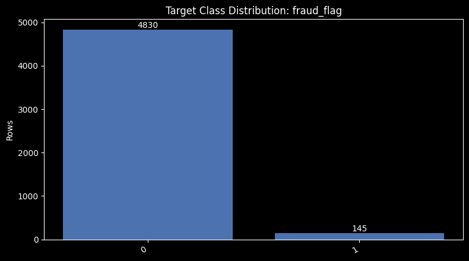

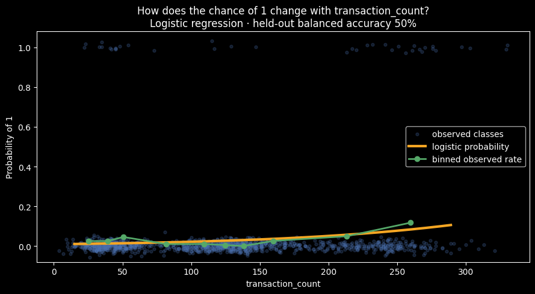

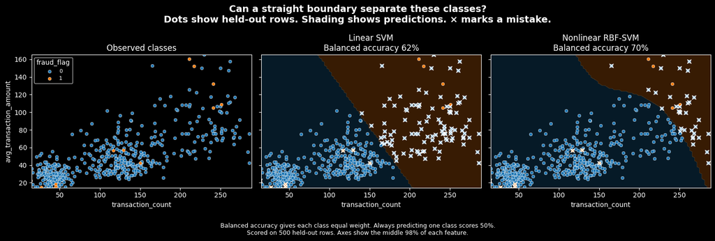

```
Visual ML signals
  - Possible target leakage: fraud_risk_score has a near-deterministic univariate association; verify when it becomes available.
  - Curved or threshold-like target structure appears in transaction_count; compare tree-based or nonlinear-kernel models.
  - Choose between linear and nonlinear classifiers with stratified validation; visual separation alone is not decisive.
```

```
NowEDA VizResult(target='fraud_flag', problem_type='classification', plots=5, selected_features=2)
```

```python
fraud = clean[["transaction_count", "avg_transaction_amount", "fraud_risk_score", "fraud_flag"]]
fraud.eda.vizall(target="fraud_flag", max_plots=5)
```

## Optional · Look for groups without a target

Suppose we only know how active and satisfied customers are. Leave out the target to look for customers who behave similarly. The colors in the clustering plot show groups the algorithm proposes. Do those groups look distinct, or do they overlap?

```
[########################] 100% NowEDA · Rendering visualizations
```

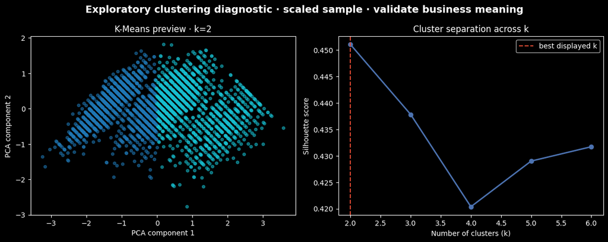

```
NowEDA VizResult(target=None, problem_type=None, plots=2, selected_features=2)
```

```python
activity = clean[["transaction_count", "satisfaction_score"]]
activity.eda.vizall(max_plots=2)
```

## Optional · Explore the whole file on disk

Earlier we read the **first** 5,000 records. Large mode keeps the file on disk. Here `sample=2_000` draws 2,000 rows from across the file, and `max_plots=1` shows the churn counts for that sample. Read the sample-size notice before interpreting the counts.

In the saved large-mode chart, `False` means the customer stayed and `True` means they left. These are the same outcomes labeled `no` and `yes` earlier. You can also set `sample=2_000` in the earlier `churn.eda.vizall()` call to explore fewer of the loaded records.

```
NowEDA large mode · vizall(): sample-based results use 2,000 of 100,000 rows. Estimates may differ from the full dataset.
```

```
[########################] 100% NowEDA · Rendering visualizations
```

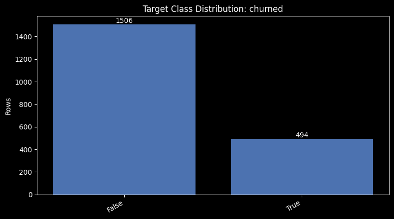

```
Visual ML signals
  - Approximately linear target structure appears in transaction_count, satisfaction_score, credit_limit; logistic regression or a linear SVM is a reasonable baseline to validate.
  - Curved or threshold-like target structure appears in support_tickets, avg_transaction_amount; compare tree-based or nonlinear-kernel models.
  - Choose between linear and nonlinear classifiers with stratified validation; visual separation alone is not decisive.
```

```
NowEDA VizResult(target='churned', problem_type='classification', plots=1, selected_features=0)
```

```python
large_data = eda.read(file_name, mode="large")
large_data.eda.vizall(target="churned", sample=2_000, max_plots=1)
```

For more examples, see the guides to [reading files in chunks](https://codewithdaniel1.github.io/NowEDA/user-guide/reading-data/), [exporting an HTML report](https://codewithdaniel1.github.io/NowEDA/html-reports/), and [writing a custom plugin](https://codewithdaniel1.github.io/NowEDA/examples/custom-plugin/).